# 308.1. Solar System orbit classifications

For the Rubin Science Platform at data.lsst.cloud.  
Data Release: [Data Preview 2](https://dp2.lsst.io/)  
Container Size: Large  
LSST Science Pipelines version: r30.0.9  
Last verified to run: 2026-07-20  
Repository: github.com/lsst/tutorial-notebooks  
DOI: 10.11578/rubin/dc.20250909.20

**Learning objective:** An overview of the Data Preview 2 (DP2) Solar System object orbits.

**LSST data products:** `mpc_orbits`, `SSObject`

**Packages:** `lsst.rsp`

**Credit:** Originally developed by the Rubin Community Science team. Please consider acknowledging them if this notebook is used for the preparation of journal articles, software releases, or other notebooks.

**Get Support:** Everyone is encouraged to ask questions or raise issues in the [Support Category](https://community.lsst.org/c/support) of the Rubin Community Forum. Rubin staff will respond to all questions posted there.

## 1. Introduction

This notebook examines the orbital classifications in the DP2 Solar System object tables. The DP2 data release `mpc_orbits` table contains 1,505,545 Solar System objects, with 299,343 objects detected by Rubin (accessible via the `SSObject` table).

Related tutorials: The 100-level tutorials demonstrate how to use the TAP service. The 200-level tutorials introduce the types of catalog data.

### 1.1. Import packages

Import `numpy`, a fundamental package for scientific computing with arrays in Python (numpy.org), and `matplotlib`, a comprehensive library for data visualization ([matplotlib.org](https://matplotlib.org/); [matplotlib gallery](https://matplotlib.org/stable/gallery/index.html)).

From the `lsst` package, import the module for accessing the Table Access Protocol (TAP) service from the LSST Science Pipelines ([pipelines.lsst.io](https://pipelines.lsst.io/)).

```python
import numpy as np
import pandas as pd
import matplotlib.pyplot as plt
from lsst.rsp import RSPDiscovery
```

### 1.2. Define parameters and functions

Create an instance of the TAP service.

```python
discovery = RSPDiscovery("dp2")
service = discovery.get_tap_client()
```

Define parameters to use colorblind-friendly colors with `matplotlib`.

```python
plt.style.use('seaborn-v0_8-colorblind')
prop_cycle = plt.rcParams['axes.prop_cycle']
colors = prop_cycle.by_key()['color']
```

The `orbit_type_int` field in the `mpc_orbits` catalog contains a set of integers used by the IAU Minor Planet Center (MPC) to define Solar System object orbit types based on the object's semimajor axis $a$, eccentricity $e$, and inclination $i$. For the orbit type definitions, see the [Minor Planet Center](https://www.minorplanetcenter.net/mpcops/documentation/orbit-types/) website.

The orbit type and their MPC-assigned integer values are as follows:

Orbit type | Assigned value  
----------------------------  
Atira NEO | 0  
Aten NEO | 1  
Apollo NEO | 2  
Amor NEO | 3  
Other - Inner Solar System | 9  
Mars Crosser | 10  
Main Belt | 11  
Jupiter Trojan | 12  
Other - Middle Solar System | 19  
Jupiter Coupled | 20  
Neptune Trojan | 21  
Centaur | 22  
Transneptunian object | 23  
Hyperbolic | 30  
Parabolic | 31  
Other - unusual | 99  
None | None

Define a function to assign orbit classification labels based on the MPC-assigned orbit type, where `ATI` = Atira NEO, `ATE` = Aten NEO, `APO` = Apollo NEO, `AMO` = Amor NEO, `O-I` = Other-Inner Solar System, `MCA` = Mars-crosser asteroid, `MBA` = main-belt asteroid, `TJN` = Jupiter Trojan, `O-M` = Other-Middle Solar System, `J-C` = Jupiter coupled, `NTR` = Neptune Trojan, `CEN` = Centaur, `TNO` = transneptunian object, `HYA` = hyperbolic asteroid, `PAA` = parabolic asteroid, `O-U` = Other-unusual, and `NAN` = None, following the MPC orbit type definitions above.

> **Notice**: Many objects in the `mpc_orbits` table have no value in their `orbit_type_int` fields. A search on `orbit_type_int == 0` thus returns both Atiras and all objects with no `orbit_type_int` values. To separate out the Atiras, use the perihelion distance ($q$) and eccentricity ($e$) to restrict objects to those with aphelion distance 0 au < $Q$ < 0.983 au (orbital definition for Atiras, i.e., objects with aphelia less than Earth's perihelion distance). The orbital element relationship for aphelion distance is defined by $Q = q * (1 + e) / (1 - e)$. The pericenter distance $q$ is used instead of the semimajor axis $a$, because many semimajor axis entries are missing from the `mpc_orbits` table (see Section 2 for more details). All objects with no `orbit_type_int` values are assigned the `AST` (asteroid) classification label.

```python
def assign_orbit_class(Q, orbit_type_int):

    orbit_class = np.full(len(orbit_type_int), "AST")

    orbit_class_dict = {
        "ATI": np.where((Q < 0.983) & (Q > 0)),
        "ATE": np.where((orbit_type_int == 1)),
        "APO": np.where((orbit_type_int == 2)),
        "AMO": np.where((orbit_type_int == 3)),
        "O-I": np.where((orbit_type_int == 9)),
        "MCA": np.where((orbit_type_int == 10)),
        "MBA": np.where((orbit_type_int == 11)),
        "TJN": np.where((orbit_type_int == 12)),
        "O-M": np.where((orbit_type_int == 19)),
        "J-C": np.where((orbit_type_int == 20)),
        "NTR": np.where((orbit_type_int == 21)),
        "CEN": np.where((orbit_type_int == 22)),
        "TNO": np.where((orbit_type_int == 23)),
        "HYA": np.where((orbit_type_int == 30)),
        "PAA": np.where((orbit_type_int == 31)),
        "O-U": np.where((orbit_type_int == 99)),
        "NAN": np.where((orbit_type_int == 'None')),
    }
    for c, v in orbit_class_dict.items():
        orbit_class[v] = c

    return orbit_class
```

## 2. Classify orbits

Query the `mpc_orbits` table for the orbital parameters for all 1,505,545 Solar System objects in this DP2 table, including those detected by Rubin.

```python
query = "SELECT mpc.designation, "\
        "mpc.q, mpc.e, mpc.i, "\
        "mpc.orbit_type_int "\
        "FROM dp2.mpc_orbits as mpc "\
        "ORDER BY mpc.designation ASC"
```

```python
job = service.submit_job(query)
job.run()
job.wait(phases=['COMPLETED', 'ERROR'])
print('Job phase is', job.phase)
if job.phase == 'ERROR':
    job.raise_if_error()
```

```
Job phase is COMPLETED
```

Fetch the job results and assign to an astropy `result` table.

```python
assert job.phase == 'COMPLETED'
result = job.fetch_result()
len(result)
```

```
1505545
```

Convert the `result` astropy table to a pandas dataframe.

```python
result_df = pd.DataFrame(result)
```

Calculate the aphelion distance $Q$ from the perihelion distance ($q$) and eccentricity ($e$) using the relationship $Q = q * (1 + e) / (1 - e)$ and add as a new column in the `result_df` dataframe.

```python
result_df['Q'] = result_df['q'] * (1.0 + result_df['e']) / (1.0 - result_df['e'])
```

Add a column to `result_df` with each object's `orbit_class`.

```python
result_df['orbit_class'] = assign_orbit_class(result_df['Q'], result_df['orbit_type_int'])
```

Option to print the results

```python
# result_df
```

Print the number of objects in each orbit class.

```python
print("atira: ", len(result_df[result_df['orbit_class'] == 'ATI']))
print("aten: ", len(result_df[result_df['orbit_class'] == 'ATE']))
print("apollo: ", len(result_df[result_df['orbit_class'] == 'APO']))
print("amor: ", len(result_df[result_df['orbit_class'] == 'AMO']))
print("other_inner_ss: ", len(result_df[result_df['orbit_class'] == 'O-I']))
print("mars_crosser: ", len(result_df[result_df['orbit_class'] == 'MCA']))
print("mba: ", len(result_df[result_df['orbit_class'] == 'MBA']))
print("jupiter_trojan: ", len(result_df[result_df['orbit_class'] == 'TJN']))
print("other_middle_ss: ", len(result_df[result_df['orbit_class'] == 'O-M']))
print("jupiter_coupled: ", len(result_df[result_df['orbit_class'] == 'J-C']))
print("neptune_trojan: ", len(result_df[result_df['orbit_class'] == 'NTR']))
print("centaur: ", len(result_df[result_df['orbit_class'] == 'CEN']))
print("tno: ", len(result_df[result_df['orbit_class'] == 'TNO']))
print("hyperbolic: ", len(result_df[result_df['orbit_class'] == 'HYA']))
print("parabolic: ", len(result_df[result_df['orbit_class'] == 'PAA']))
print("other_unusual: ", len(result_df[result_df['orbit_class'] == 'O-U']))
print("none: ", len(result_df[result_df['orbit_class'] == 'NAN']))
print("ast: ", len(result_df[result_df['orbit_class'] == 'AST']))
```

```
atira:  39
aten:  710
apollo:  4438
amor:  3253
```

```
other_inner_ss:  0
mars_crosser:  12639
mba:  968235
```

```
jupiter_trojan:  13077
other_middle_ss:  8084
jupiter_coupled:  2485
neptune_trojan:  19
```

```
centaur:  269
tno:  2072
hyperbolic:  37
parabolic:  0
```

```
other_unusual:  0
none:  0
ast:  490188
```

The semimajor axis is included in the `mpc_orbits` table, but many entries are missing, as described in Section 1. For further information on the known issues with the `mpc_orbits` table, see the [MPC documentation](https://minorplanetcenter.net/mpcops/documentation/mpc-orbits/). The semimajor axis ($a$) can be computed from the perihelion distance ($q$) and eccentricity ($e$) using the relationship $a$ = $q$ / (1.0-$e$).

Add a column to `result_df` with the calculated semimajor axis.

```python
result_df['a_calc'] = result_df['q'] / (1.0-result_df['e'])
```

Define a dataframe splitting the inner Solar System (with semimajor axes 0 < $a$ <= 10 au) from `result_df`. Remove all orbital classes with no objects from object counts above and the large number of objects classified as 'AST'.

```python
inner_ss = result_df[result_df['a_calc'] <= 10.0]
inner_ss = inner_ss[inner_ss['a_calc'] > 0.0]
inner_ss.drop(inner_ss[inner_ss['orbit_class'] == 'O-I'].index, inplace=True)
inner_ss.drop(inner_ss[inner_ss['orbit_class'] == 'HYA'].index, inplace=True)
inner_ss.drop(inner_ss[inner_ss['orbit_class'] == 'PAA'].index, inplace=True)
inner_ss.drop(inner_ss[inner_ss['orbit_class'] == 'O-U'].index, inplace=True)
inner_ss.drop(inner_ss[inner_ss['orbit_class'] == 'NAN'].index, inplace=True)
inner_ss.drop(inner_ss[inner_ss['orbit_class'] == 'AST'].index, inplace=True)
```

Define a dataframe splitting the outer Solar System (with semimajor axes 10 au < $a$ < 100 au) from `result_df`. Remove all orbital classes with no objects from object counts above from object counts above and the large number of objects classified as 'AST'.

```python
outer_ss = result_df[result_df['a_calc'] > 10.0]
outer_ss = outer_ss[outer_ss['a_calc'] < 100.0]
outer_ss.drop(outer_ss[outer_ss['orbit_class'] == 'O-I'].index, inplace=True)
outer_ss.drop(outer_ss[outer_ss['orbit_class'] == 'HYA'].index, inplace=True)
outer_ss.drop(outer_ss[outer_ss['orbit_class'] == 'PAA'].index, inplace=True)
outer_ss.drop(outer_ss[outer_ss['orbit_class'] == 'O-U'].index, inplace=True)
outer_ss.drop(outer_ss[outer_ss['orbit_class'] == 'NAN'].index, inplace=True)
outer_ss.drop(outer_ss[outer_ss['orbit_class'] == 'AST'].index, inplace=True)
```

Plot the semimajor axes, eccentricities, and inclinations of the 1,505,545 Solar System objects in the DP2 `mpc_orbits` table, distinguishing each orbital class.

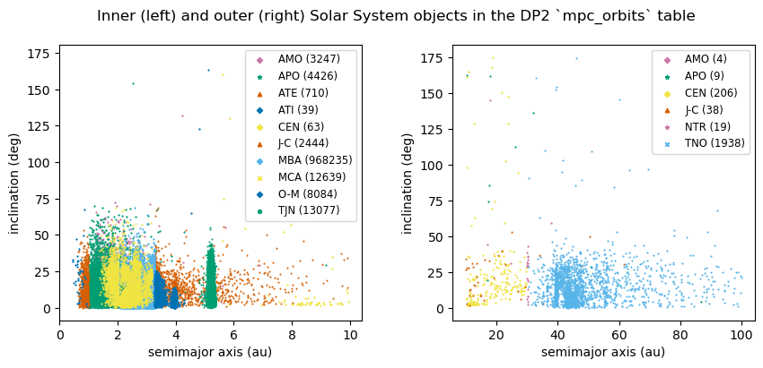

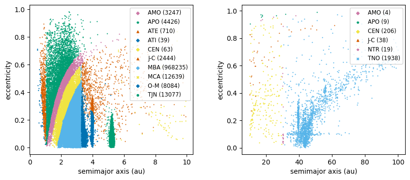

```python
fig, axes = plt.subplots(1, 2, figsize=(10, 4))

for ax, oo in zip(axes, (inner_ss, outer_ss)):
    for label, orb in oo.groupby('orbit_class'):
        if label == 'ATI':
            marker = "D"
            color = colors[0]
        elif label == 'ATE':
            marker = "^"
            color = colors[2]
        elif label == 'APO':
            marker = "*"
            color = colors[1]
        elif label == 'AMO':
            marker = "D"
            color = colors[3]
        elif label == 'MCA':
            marker = "x"
            color = colors[4]
        elif label == 'MBA':
            marker = "D"
            color = colors[5]
        elif label == 'TJN':
            marker = "h"
            color = colors[1]
        elif label == 'O-M':
            marker = "D"
            color = colors[0]
        elif label == 'J-C':
            marker = "^"
            color = colors[2]
        elif label == 'NTR':
            marker = "*"
            color = colors[3]
        elif label == 'CEN':
            marker = "D"
            color = colors[4]
        elif label == 'TNO':
            marker = "x"
            color = colors[5]
        ax.scatter(orb["a_calc"], orb["i"],
                   s=0.3, marker=marker, color=color,
                   label=f"{label} ({len(orb)})")

    for handle in ax.legend(fontsize="small", loc="upper right").legend_handles:
        handle.set_sizes([10])
    ax.set_xlabel("semimajor axis (au)")
    ax.set_ylabel("inclination (deg)")

plt.subplots_adjust(wspace=0.3)

fig.suptitle("Inner (left) and outer (right) Solar System objects in the DP2 `mpc_orbits` table")

fig, axes = plt.subplots(1, 2, figsize=(10, 4))

for ax, oo in zip(axes, (inner_ss, outer_ss)):
    for label, orb in oo.groupby('orbit_class'):
        if label == 'ATI':
            marker = "D"
            color = colors[0]
        elif label == 'ATE':
            marker = "^"
            color = colors[2]
        elif label == 'APO':
            marker = "*"
            color = colors[1]
        elif label == 'AMO':
            marker = "D"
            color = colors[3]
        elif label == 'MCA':
            marker = "x"
            color = colors[4]
        elif label == 'MBA':
            marker = "D"
            color = colors[5]
        elif label == 'TJN':
            marker = "h"
            color = colors[1]
        elif label == 'O-M':
            marker = "D"
            color = colors[0]
        elif label == 'J-C':
            marker = "^"
            color = colors[2]
        elif label == 'NTR':
            marker = "*"
            color = colors[3]
        elif label == 'CEN':
            marker = "D"
            color = colors[4]
        elif label == 'TNO':
            marker = "x"
            color = colors[5]
        ax.scatter(orb["a_calc"], orb["e"],
                   s=0.3, marker=marker, color=color,
                   label=f"{label} ({len(orb)})")

    for handle in ax.legend(fontsize="small", loc="upper right").legend_handles:
        handle.set_sizes([10])
    ax.set_xlabel("semimajor axis (au)")
    ax.set_ylabel("eccentricity")

plt.subplots_adjust(wspace=0.3)
```

> **Figure 1:** Semimajor axes, eccentricities, and inclinations of the 1,505,545 Solar System objects in the DP2 `mpc_orbits` table, with the colors distinguishing each orbital class. Left: inner Solar System (semimajor axis $a$ < 10 au). Right: outer Solar System (truncated at semimajor axis 10 au > $a$ > 100 au). The number of objects in each orbital class is indicated in the figure legend.

Clean up.

```python
del query, result
```

## 3. Rubin detections

The DP2 `mpc_orbits` and `SSObject` tables are too large (1,505,545, and 299,343 rows, respectively) to query both for the orbital parameters of all Rubin-detected DP2 Solar System objects without long query times. To avoid long query times on joined tables, query the `SSObject` table separately and merge the results as a dataframe with `result_df` from the query above on the `mpc_orbits` table.

```python
query = "SELECT designation "\
        "FROM dp2.SSObject "\
        "ORDER BY designation ASC"
```

```python
job = service.submit_job(query)
job.run()
job.wait(phases=['COMPLETED', 'ERROR'])
print('Job phase is', job.phase)
if job.phase == 'ERROR':
    job.raise_if_error()
```

```
Job phase is COMPLETED
```

Fetch the job results and assign to an astropy `result` table.

```python
assert job.phase == 'COMPLETED'
result = job.fetch_result()
```

Convert the `result` astropy table to a pandas dataframe.

```python
result_df_rubin = pd.DataFrame(result)
```

Option to print the results

```python
# result_df_rubin
```

Merge the `result_df` dataframe from the `mpc_orbits` query above with the `result_df_rubin` dataframe containing only Rubin-detected objects. Use an `inner` merge to only keep matching rows present in both dataframes.

```python
merged_df = pd.merge(result_df, result_df_rubin, on='designation', how='inner')
len(merged_df)
```

```
299343
```

Print the number of objects detected by Rubin in each orbit class.

```python
print("atira: ", len(merged_df[merged_df['orbit_class'] == 'ATI']))
print("aten: ", len(merged_df[merged_df['orbit_class'] == 'ATE']))
print("apollo: ", len(merged_df[merged_df['orbit_class'] == 'APO']))
print("amor: ", len(merged_df[merged_df['orbit_class'] == 'AMO']))
print("other_inner_ss: ", len(merged_df[merged_df['orbit_class'] == 'O-I']))
print("mars_crosser: ", len(merged_df[merged_df['orbit_class'] == 'MCA']))
print("mba: ", len(merged_df[merged_df['orbit_class'] == 'MBA']))
print("jupiter_trojan: ", len(merged_df[merged_df['orbit_class'] == 'TJN']))
print("other_middle_ss: ", len(merged_df[merged_df['orbit_class'] == 'O-M']))
print("jupiter_coupled: ", len(merged_df[merged_df['orbit_class'] == 'J-C']))
print("neptune_trojan: ", len(merged_df[merged_df['orbit_class'] == 'NTR']))
print("centaur: ", len(merged_df[merged_df['orbit_class'] == 'CEN']))
print("tno: ", len(merged_df[merged_df['orbit_class'] == 'TNO']))
print("hyperbolic: ", len(merged_df[merged_df['orbit_class'] == 'HYA']))
print("parabolic: ", len(merged_df[merged_df['orbit_class'] == 'PAA']))
print("other_unusual: ", len(merged_df[merged_df['orbit_class'] == 'O-U']))
print("none: ", len(merged_df[merged_df['orbit_class'] == 'NAN']))
print("ast: ", len(merged_df[merged_df['orbit_class'] == 'AST']))
```

```
atira:  0
aten:  44
apollo:  376
amor:  494
other_inner_ss:  0
mars_crosser:  2380
mba:  229552
jupiter_trojan:  378
```

```
other_middle_ss:  2168
jupiter_coupled:  646
neptune_trojan:  3
centaur:  38
tno:  670
hyperbolic:  3
parabolic:  0
other_unusual:  0
none:  0
ast:  62591
```

Similar to above, define a dataframe splitting the inner Solar System (with semimajor axes 0 < $a$ <= 10 au) from `result_df_rubin`. Remove all orbital classes with no objects from object counts above from object counts above and the large number of objects classified as 'AST'.

```python
inner_ss_rubin = merged_df[merged_df['a_calc'] <= 10.0]
inner_ss_rubin = inner_ss_rubin[inner_ss_rubin['a_calc'] > 0.0]
inner_ss_rubin.drop(inner_ss_rubin[inner_ss_rubin['orbit_class'] == 'ATI'].index, inplace=True)
inner_ss_rubin.drop(inner_ss_rubin[inner_ss_rubin['orbit_class'] == 'O-I'].index, inplace=True)
inner_ss_rubin.drop(inner_ss_rubin[inner_ss_rubin['orbit_class'] == 'HYA'].index, inplace=True)
inner_ss_rubin.drop(inner_ss_rubin[inner_ss_rubin['orbit_class'] == 'PAA'].index, inplace=True)
inner_ss_rubin.drop(inner_ss_rubin[inner_ss_rubin['orbit_class'] == 'O-U'].index, inplace=True)
inner_ss_rubin.drop(inner_ss_rubin[inner_ss_rubin['orbit_class'] == 'NAN'].index, inplace=True)
inner_ss_rubin.drop(inner_ss_rubin[inner_ss_rubin['orbit_class'] == 'AST'].index, inplace=True)
```

Define a dataframe splitting the outer Solar System (with semimajor axes 10 au < $a$ < 700 au) from `result_df_rubin`. Remove all orbital classes with no objects from object counts above from object counts above and the large number of objects classified as 'AST'.

```python
outer_ss_rubin = merged_df[merged_df['a_calc'] > 10.0]
outer_ss_rubin = outer_ss_rubin[outer_ss_rubin['a_calc'] < 700.0]
outer_ss_rubin.drop(outer_ss_rubin[outer_ss_rubin['orbit_class'] == 'ATI'].index, inplace=True)
outer_ss_rubin.drop(outer_ss_rubin[outer_ss_rubin['orbit_class'] == 'O-I'].index, inplace=True)
outer_ss_rubin.drop(outer_ss_rubin[outer_ss_rubin['orbit_class'] == 'HYA'].index, inplace=True)
outer_ss_rubin.drop(outer_ss_rubin[outer_ss_rubin['orbit_class'] == 'PAA'].index, inplace=True)
outer_ss_rubin.drop(outer_ss_rubin[outer_ss_rubin['orbit_class'] == 'O-U'].index, inplace=True)
outer_ss_rubin.drop(outer_ss_rubin[outer_ss_rubin['orbit_class'] == 'NAN'].index, inplace=True)
outer_ss_rubin.drop(outer_ss_rubin[outer_ss_rubin['orbit_class'] == 'AST'].index, inplace=True)
```

Plot the semimajor axes, eccentricities, and inclinations of the 299,343 Solar System objects detected by Rubin in DP2, distinguishing each orbital class.

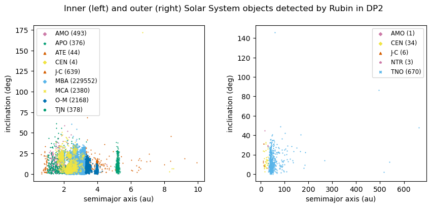

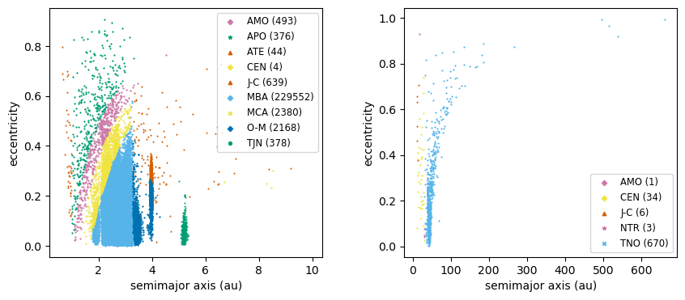

```python
fig, axes = plt.subplots(1, 2, figsize=(10, 4))

for ax, oo in zip(axes, (inner_ss_rubin, outer_ss_rubin)):
    for label, orb in oo.groupby('orbit_class'):
        if label == 'ATE':
            marker = "^"
            color = colors[2]
        elif label == 'APO':
            marker = "*"
            color = colors[1]
        elif label == 'AMO':
            marker = "D"
            color = colors[3]
        elif label == 'MCA':
            marker = "x"
            color = colors[4]
        elif label == 'MBA':
            marker = "D"
            color = colors[5]
        elif label == 'TJN':
            marker = "h"
            color = colors[1]
        elif label == 'O-M':
            marker = "D"
            color = colors[0]
        elif label == 'J-C':
            marker = "^"
            color = colors[2]
        elif label == 'NTR':
            marker = "*"
            color = colors[3]
        elif label == 'CEN':
            marker = "D"
            color = colors[4]
        elif label == 'TNO':
            marker = "x"
            color = colors[5]
        ax.scatter(orb["a_calc"], orb["i"],
                   s=0.3, marker=marker, color=color,
                   label=f"{label} ({len(orb)})")

    for handle in ax.legend(fontsize="small").legend_handles:
        handle.set_sizes([10])
    ax.set_xlabel("semimajor axis (au)")
    ax.set_ylabel("inclination (deg)")

plt.subplots_adjust(wspace=0.3)

fig.suptitle("Inner (left) and outer (right) Solar System objects detected by Rubin in DP2")

fig, axes = plt.subplots(1, 2, figsize=(10, 4))

for ax, oo in zip(axes, (inner_ss_rubin, outer_ss_rubin)):
    for label, orb in oo.groupby('orbit_class'):
        if label == 'ATE':
            marker = "^"
            color = colors[2]
        elif label == 'APO':
            marker = "*"
            color = colors[1]
        elif label == 'AMO':
            marker = "D"
            color = colors[3]
        elif label == 'MCA':
            marker = "x"
            color = colors[4]
        elif label == 'MBA':
            marker = "D"
            color = colors[5]
        elif label == 'TJN':
            marker = "h"
            color = colors[1]
        elif label == 'O-M':
            marker = "D"
            color = colors[0]
        elif label == 'J-C':
            marker = "^"
            color = colors[2]
        elif label == 'NTR':
            marker = "*"
            color = colors[3]
        elif label == 'CEN':
            marker = "D"
            color = colors[4]
        elif label == 'TNO':
            marker = "x"
            color = colors[5]
        ax.scatter(orb["a_calc"], orb["e"],
                   s=0.3, marker=marker, color=color,
                   label=f"{label} ({len(orb)})")

    for handle in ax.legend(fontsize="small").legend_handles:
        handle.set_sizes([10])
    ax.set_xlabel("semimajor axis (au)")
    ax.set_ylabel("eccentricity")

plt.subplots_adjust(wspace=0.3)
```

> **Figure 2:** Semimajor axes, eccentricities, and inclinations of the 299,343 Rubin-detected DP2 Solar System objects, with the colors distinguishing each orbital class. Left: inner Solar System (semimajor axis $a$ < 10 au). Right: outer Solar System (truncated at semimajor axis 10 au > $a$ > 700 au). The number of objects in each orbital class is indicated in the figure legend.

Clean up.

```python
del query, result, result_df, inner_ss, outer_ss
del result_df_rubin, merged_df, inner_ss_rubin, outer_ss_rubin
```